# Manifold Learning

#### Laplacian on $\mathcal M$: The [Laplace-Beltrami Operator](https://en.wikipedia.org/wiki/Laplace%E2%80%93Beltrami_operator):

The L-B operator $\Delta_\mu$ acting on a twice differentiable function $f: \mathcal M \to \mathbb R$ is defined as the divergence of the gradient:

$$\Delta_\mathcal M f \equiv \text{div
grad}(f)$$
In local coordinates, for chart $(U,x),$ the L-B operator is expressed by means of $g:$

$$\Delta_\mathbb M f =
\frac{1}{\sqrt{\det(g)}}\frac{\partial}{\partial
x^l}\left(\sqrt{\det(g)}g^{lk}\frac{\partial}{\partial x^k} f\right
).$$

The L-B operator contains all the geometry of the object, and at the same time, it is coordinate free.

#### Obtaining the Riemannian Metric:

Given the coordinate chart $(U,x)$ of a smooth R.Manifold, $M$ and $\Delta_\mu$ defined on $M,$ then the $g(p)^{-1},$ the inverse of the RM at point $p\in U$ as expressed in local coordinates $x$ can be derived from

$$g^{ij}=\frac{1}{2}\Delta_\mu (x^i -
x^i(p))\,(x^j - x^j (p))\rvert_{x^i=x^i(p),x^j=x^j(p)}$$

with $i,j=1,\dots, d.$

For an embedding this takes the form

$$\tilde h^{ij}=\frac{1}{2}\Delta_M\;
(f^i-f^i(p))\,(f^j-f^j(p))\rvert_{f^i=f^i(p),f^j=f^j(p)}$$

and so $h(p)$ is given by the pseudoinverse $\tilde h.$

#### Discretized problem:

The input level for the embedding algorith is a set of points $\mathcal D =p_1,\dots,p_n\subset M.$ These points are assumed to be a sample from the distribution

$$p(x) = e^{-U(x)}$$
on $M,$ absolutely continuous with respect to the Lebesgue measure on $M.$

Embedding algorithms construct a map $f_n: \mathcal D\to \mathbb R^\mathcal s.$

We go on to define the symmetric positive semidefinite embedding pushforward $h_n$ on the set of points $\mathcal D.$ We obtain it by defining a discrete estimator $\tilde{ \mathcal L}_{n,\epsilon}$ that is consistent with $\Delta_M.$ The idea being to get an approximation of the Laplacian.

#### Random Walk Graph Laplacian:

Construct graph $g_n$ to have adjacency matrix $k_n =[k_\epsilon(p,p')]_{p,p'\in \mathcal D}$ given by $k_\epsilon(p,p') = \exp(-\Vert p-p'\Vert^2/\epsilon),$ which is the Gaussian kernel.

If the sampling density is uniform over $M,$ then one can immediately construct the random walk graph Laplacian:

$$\mathcal L_{n,\epsilon}\equiv \frac{I_n
- T_n^{-1}k_n}{\epsilon}$$

where $T_n$ is the diagonal matrix of outdegrees, i.e. $T_n= \text{diag}\left\{t(p), p\in \mathcal D \right\}$ with $t(p) =\sum_{p'\in \mathcal D}k_n(p,p').$

A simple renormalization exists when $p(x)$ is not uniform.

#### Algorithm to learn the metric:

1. Construct the graph Laplacian $\tilde{\mathcal L}_{n,\epsilon}$
2. Obtain the embedding coordinates $f_n(p) =\left( f_n^1(p),\dots,f_n^\mathcal s (p) \right)$ of each point $p \in \mathcal D$ by $[f_n(p)]_{p\in \mathcal D}\equiv \text{GENERIC EMBED}(\mathcal D,\mathcal s, \epsilon_n)$
3. Calculate the embedding metric $h_n(p)$ at each point, using $\tilde{\mathcal L}_{n,\epsilon}$. Output $\left( f_n(p), h_n(p) \right)_{p\in \mathcal D}.$

#### Locally Isometric Embedding:

Using the pushforward metric $h_p$ at point $p \in M,$ we can construct an affine tranformation of $f$ that defines a local isometry at $p:$

Given $(f(\mathcal D), h(\mathcal D))$ metric embedding of $\mathcal D:$

1. Select a point $p\in \mathcal D$ on the manifold
2. Transform coordinates $\tilde f(p') \leftarrow h_p^{-1/2}\,f(p')$ for $p'\in \mathcal D$

Display $\mathcal D$ in coordinates $\tilde f$

#### Computing Geodesic Distance:

Computing the geodesic distance between two points $p$ and $p'$ requires discretizing the arclength integral and finding the shortest path:

$$\hat d_\mathcal M \,(f(P),f(p'))=
\min\left \{ \sum_{i=1}^l \mathcal H_{q_i,q_{i-1}},l\geq 1,
(q_0=p,\dots,q_1=p')\in\mathcal G \right\}$$

where $\hat d$ is the metric, $\Vert f(p) - f(p')\Vert$ is the distance between two points and $d_\mathcal G$ the shortest path.

$$\mathcal H_{q_i,q_{i-1}}=
\frac{1}{2}\sqrt{(f(q_i)-f(q_{i-1}))'\,h_{q_i}(f(q_i)-f(q_{i-1}))}+
\frac{1}{2}\sqrt{(f(q_i)-f(q_{i-1}))'\,h_{q_{i-1}}(f(q_i)-f(q_{i-1}))}$$

The computation can be done regardless of the embedding.

#### Computing Area and Volume:

By performing a Voronoi tessellation of a coordinate chart $(U,x)$ we can obtain the estimator $\Delta x^1,\dots \Delta x^d$ around $p$ and multiply it by $\sqrt{\det (h)}$ to obtain $\Delta \text{Vol}\approx d\text{Vol}.$ Summing over all points in a set $W\subset \mathcal M$ gives the estimator:

$$\small \text{Vol}(W) =\sum_{p\in W}
\sqrt{\det(h_p)}\Delta x^1(p),\dots \Delta x^d(p).$$

#### Gaussian Processes on Manifolds:

GP’s can be extended to M via SPDE’s. Let $(k^2 - \Delta_{\mathbb R^d})^{\alpha/2}u(x) = \xi$ with $\xi$ Gaussian with noise, then $u(x)$ is a Matérn GP. Substituting $\Delta_\mathcal M$ allows us to define a Matérn GP on $\mathcal M.$

Unlabelled points can be learned by GP regression (semi-supervised learning) using the covariance matrix $\Sigma=(k^2 - \Delta_{\mathbb R^d})^{-\alpha}$ of GP $u(x).$

From this [youtube video](https://youtu.be/1jlYn7M5wSk)

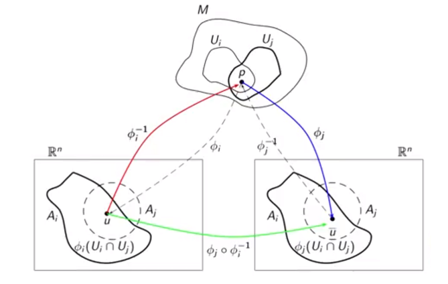

#### Riemann metric:

The context is a metric $g_{\alpha\beta},$ which in full notation would be a (0,2) tensor $g_{\alpha\beta}\, dx^\alpha \otimes dx^\beta,$ taking two vectors of the $T_p(M)$ to the real line. Since $g_{\alpha\beta}$ is a function of space-time, i.e. $g_{\alpha\beta}(x)$ with $x=( x^0, x^1,x^2, x^3),$ it turns out that $g_{\alpha\beta}$ is a field.

A Riemannian metric on a differentiable manifold $M$ is a mapping that assigns to each point of the manifold $M$ an inner product $g_p$ on the tangent space $T_pM.$ Thus, for every two vector fields $X_p, Y_p \in M$, the function $g_p(X_p, Y_p)=\left<X_p,Y_p\right>_p$ is smooth. An $M$ manifold provided with a Riemannian metric is called Riemannian manifold. The metric does not depend on the choice of local coordinates. In addition it can be expressed

$$g_p(X_p, Y_p) =\sum_{i,j}^n
v_i\,w_j\,\left< \partial_{i\vert p, \partial_{j\vert
p}} \right>$$

with $\large \partial_i =\frac{\partial}{\partial x_i},$

where $v_i$ and $w_j$ are the coefficients in the representation of $X_p$ and $Y_p$ in the canonical basis of the tangent space $T_p(M)$ given by $\{\partial_{1\vert p},\dots,\partial_{n\vert p}\}.$ The terms $g_{ij}(p)$ represent the entries of the matrix $g(p),$ which is symmetric and definite positive.

The existence of the metric allows defining the length of vectors (of curves). The curve for which the shortest distance is presented is called geodesic.

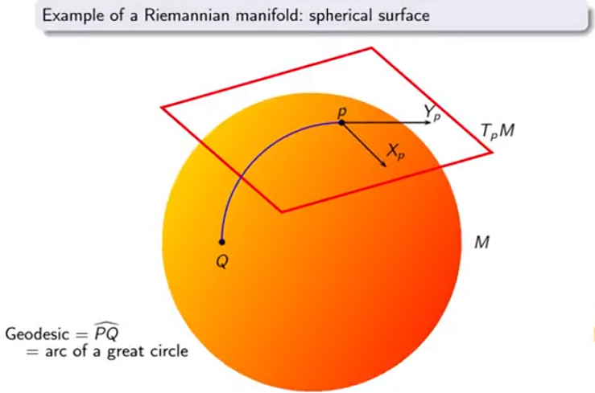

#### Laplacian operator:

Let $(M,g)$ be a Riemannian manifold. For any smooth function $f$ over $M,$ the gradient is defined as the vector field $\text{grad}(f)$ in $T(M)$ that satisfies $\left<\text{grad}(f), X(f) \right>_g= X(f)$ for all $X\in T(M).$ In local coordinates, the gradient is written as

$$(\text{grad(f)})_i =\sum_j
g^{ij}\,\frac{\partial f}{\partial x_j},$$
where $g^{ij}$ are the components of the inverse matrix of $g=[g_{ij}].$ Then

$$\text{grad}(f) =
\sum_{i,j=1}^n \underbrace{\left(g^{ij} \frac{\partial f}{\partial x_j}
\right)}_{\text{grad}(f)}\partial_i$$

In the same local coordinates, the divergent of $X$ is written

$$\text{div}(X) = \frac{1}{\sqrt{\det
g}}\sum_i \frac{\partial}{\partial x_i}\left(\sqrt{\det
g}\,X_i\right)$$
The Laplacian or Laplace-Beltrami operator on $(M,g)$ of a smooth function $f: M\to \mathbb R$ is defined as:

$$\Delta_g \, f = \text{div(grad)}(f))=
\frac{1}{\sqrt{\det g}}\sum_j \frac{\partial}{\partial x_j}\left(\sum_i
g^{ij}\sqrt{\det g}\,\frac{\partial f}{\partial X_i}\right)$$

The Laplacian operator has to do with partial derivatives.

In the usual case, the *gradient* applied to a *function* $f$ is

$$\text{grad}(f) =\left< \frac{\partial
f}{\partial x},\frac{\partial f}{\partial y}.\frac{\partial f}{\partial
z}\right >$$

in this case the basis is $\vec i, \vec j, \vec k;$ however in the case under study the basis is formed by the partials $\partial i =\frac{\partial}{\partial i}.$

This gradient determines a vectorial field $X$

$$X = \text{grad}(f) =\left<
\frac{\partial f}{\partial x},\frac{\partial f}{\partial
y},\frac{\partial f}{\partial z}\right >$$

*Divergence* applied to this vector field,

$$\text{div}(X)=\frac{\partial
X_1}{\partial x}+\frac{\partial X_2}{\partial y}+\frac{\partial
X_3}{\partial z}$$

it will produce the Laplacian of the function:

$$\Delta f =
\text{div}\left(\text{grad}(f)\right)= \frac{\partial^2 f}{\partial
x^2}+\frac{\partial^2 f}{\partial y^2}+\frac{\partial^2 f}{\partial
z^2}$$

I presume we would need exponential maps to draw geodesic lines on the manifold.

[Home Page](http://rinterested.github.io/statistics/index.html)

**NOTE: These are tentative notes on different topics for personal use - expect mistakes and misunderstandings.**